# Predator and Prey Body Sizes in Marine Food Webs

Maisie Beckett

30/10/2020

## About the Data

This data found by Barnes et al looks at the relationships between predator and prey size. This is an important thing to understand as this information is needed to describe interactions of species and size classes in food webs. The data contains 34931 records covering a variety of environmental conditions from the poles to the tropics ober 27 locations, and for 93 types of predator ranging from just 0.1mg to over 415kg and for 174 prey types with sizes ranging from a tiny 75pg to over 4.5kg. Each record includes: predator and prey scientific names, common names, taxa, life stages and sizes, type of feeding interaction, geographic location and mean annual environmental data.

## Reading the Data into R

Firstly, I downloaded the text file from https://figshare.com/articles/dataset/Full_Archive/3529112). I then converted this to a .csv files using Microsoft Excel and read this new file into R.

```r
PredPrey <- read.csv("Predator_and_prey_body_sizes_in_marine_food_webs_vsn4.csv")
```

## Looking at the Relationship Between Predator and Prey Mass

First I would like to plot the masses of the predators and prey to see if there are any anomalies.

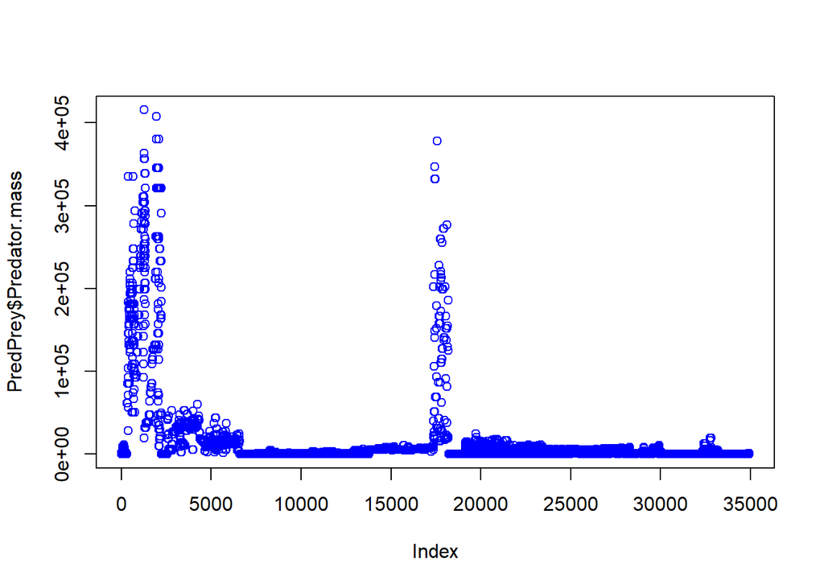

```r
plot(PredPrey$Predator.mass, col = "blue")
```

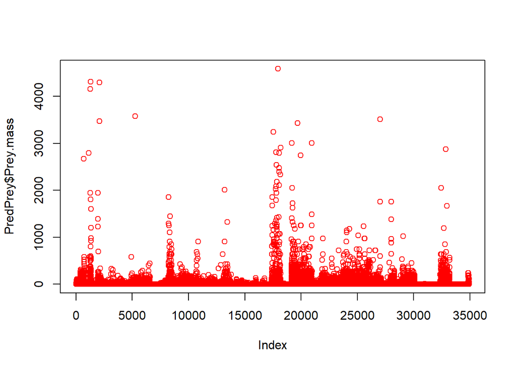

```r
plot(PredPrey$Prey.mass, col = "red")
```

In order to compare data of the different species, I would first like to check all the masses use the same units, let’s say grams.

```r
unique(PredPrey$Predator.mass.unit)
```

```
## [1] g
## Levels: g
```

```r
unique(PredPrey$Prey.mass.unit)
```

```
## [1] g  mg
## Levels: g mg
```

This shows that the prey data is presented in both grams and milligrams, so in order to make comparisons easier I will covert all the prey masses into grams.

```r
PredPrey$Prey.mass[PredPrey$Prey.mass.unit == "mg"] <- (PredPrey$Prey.mass[PredPrey$Prey.mass.unit ==
    "mg"])/1000
PredPrey$Prey.mass.unit[PredPrey$Prey.mass.unit == "mg"] <- "g"
```

I would like to plot to log of the weights of each predator with the log of the weight of its prey to see whether there is a relationship between them; I will fit a line of best fit to make this easier to recognise.

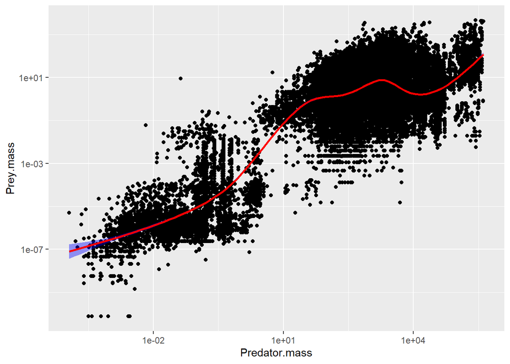

```r
ggplot(data = PredPrey, aes(x = Predator.mass, y = Prey.mass)) + geom_point() +
    geom_smooth(color = "red", fill = "blue") + scale_x_log10() + scale_y_log10()
```

This shows a positive correlation between the mass of the predator and the mass of the prey. However, according to the red line, this is not a linear relationship, as the weight of the prey gradually increases with that of the prey until a point in the upper end of the predator mass where this dips, suggesting that the relationship may be more complex than first anticipated. Also, as seen in the blue shading, the confidence interval for this regression line is larger at the beginning, where there is less data, this is as expected.

Next, I will make box plots of the weights of different predator and prey species.

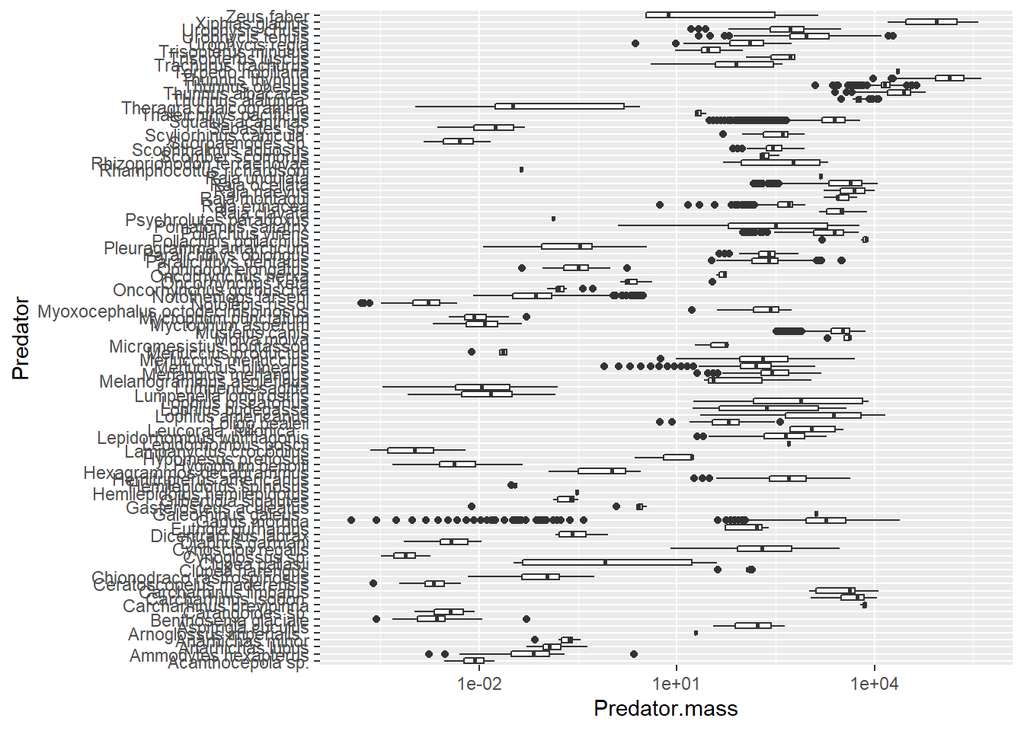

```r
ggplot(data = PredPrey) + geom_boxplot(mapping = aes(x = Predator.mass,
    y = Predator)) + scale_x_log10()
```

This is a very busy plot as there are many different predators. Therefore, this graph is not very useful for coming to conclusions.

## Trying to Recreate Graphs from Costa Paper

I have found a paper by Gabriel C. Costa which uses the data set by Barnes.It looks at predator size, prey size, and dietary niche breadth relationships in marine predators.

In order to minimise the issue of nonindependence among the sample points, Costa summarised the diet data by species and conducted a species-specific analysis which he describes in his paper. I am going to try to do a similar thing. First I will remove species with small sample sizes (<10 individuals) and larval stages. This reduces the data set to 55 species, this will reduce bias. I also need to summarise the data by species.

```r
table(PredPrey$Predator)
```

```
##
##               Acanthocepola sp.            Ammodytes hexapterus
##                              10                             136
##                Anarhichas lupus                Anarhichas minor
##                             124                              39
##        Arnoglossus imperialis                Aspitrigla cuculus
##                               1                              24
##             Benthosema glaciale                 Carangoides sp.
##                              75                               8
##         Carcharhinus brevipinna            Carcharhinus isodon
##                               4                              25
##           Carcharhinus limbatus       Ceratoscopelus maderensis
##                              86                              64
##      Chionodraco rastrospinosus                 Clupea harengus
##                             105                              13
##                 Clupea pallasii                 Cynoglossus sp.
##                              28                               7
##               Cynoscion regalis                 Diaphus garmani
##                             523                             218
##            Dicentrarchus labrax              Eutrigla gurnardus
##                            1315                               5
##                    Gadus morhua            Galeorhinus galeus
##                            2518                               1
##          Gasterosteus aculeatus           Gilbertidia sigalutes
##                              21                               6
##     Hemilepidotus hemilepidotus          Hemilepidotus spinosus
##                               1                               5
##        Hemitripterus americanus         Hexagrammos decagrammus
##                             403                              30
##                Hygophum benoiti             Hypomesus pretiosus
##                              85                               3
##          Lampanyctus crocodilus            Lepidorhombus boscii
##                              89                               1
##      Lepidorhombus whiffiagonis         Leucoraja  fullonica
##                             679                               4
##                  Loligo pealeii              Lophius americanus
##                             113                             409
##               Lophius budegassa             Lophius piscatorius
##                              55                              54
##         Lumpenella longirostris                Lumpenus sagitta
```

[output cut: 40 more lines]

```
##                               3                             162
##               Thunnus alalunga                Thunnus albacares
##                            3581                            2113
##                  Thunnus obesus                 Thunnus thynnus
##                            1898                            1909
##               Torpedo nobiliana             Trachurus trachurus
##                               4                               9
##              Trisopterus luscus             Trisopterus minutus
##                              10                              15
##                 Urophycis regia                Urophycis tenuis
##                             286                             791
##                 Urophysis chuss                 Xiphias gladius
##                             552                             827
##                      Zeus faber
##                             429
```

```r
PredPrey2 <- PredPrey[c(4, 25, 28, 45)]
PredPrey2 <- PredPrey2[PredPrey2$Predator %in% names(which(table(PredPrey2$Predator) >=
    10)), ]
table(PredPrey2$Predator)
```

```
##
##               Acanthocepola sp.            Ammodytes hexapterus
##                              10                             136
##                Anarhichas lupus                Anarhichas minor
##                             124                              39
##        Arnoglossus imperialis                Aspitrigla cuculus
##                               0                              24
##             Benthosema glaciale                 Carangoides sp.
##                              75                               0
##         Carcharhinus brevipinna            Carcharhinus isodon
##                               0                              25
##           Carcharhinus limbatus       Ceratoscopelus maderensis
##                              86                              64
##      Chionodraco rastrospinosus                 Clupea harengus
##                             105                              13
##                 Clupea pallasii                 Cynoglossus sp.
##                              28                               0
##               Cynoscion regalis                 Diaphus garmani
##                             523                             218
##            Dicentrarchus labrax              Eutrigla gurnardus
##                            1315                               0
##                    Gadus morhua            Galeorhinus galeus
##                            2518                               0
##          Gasterosteus aculeatus           Gilbertidia sigalutes
##                              21                               0
##     Hemilepidotus hemilepidotus          Hemilepidotus spinosus
##                               0                               0
##        Hemitripterus americanus         Hexagrammos decagrammus
##                             403                              30
##                Hygophum benoiti             Hypomesus pretiosus
##                              85                               0
##          Lampanyctus crocodilus            Lepidorhombus boscii
##                              89                               0
##      Lepidorhombus whiffiagonis         Leucoraja  fullonica
##                             679                               0
##                  Loligo pealeii              Lophius americanus
##                             113                             409
##               Lophius budegassa             Lophius piscatorius
##                              55                              54
##         Lumpenella longirostris                Lumpenus sagitta
```

[output cut: 40 more lines]

```
##                               0                             162
##               Thunnus alalunga                Thunnus albacares
##                            3581                            2113
##                  Thunnus obesus                 Thunnus thynnus
##                            1898                            1909
##               Torpedo nobiliana             Trachurus trachurus
##                               0                               0
##              Trisopterus luscus             Trisopterus minutus
##                              10                              15
##                 Urophycis regia                Urophycis tenuis
##                             286                             791
##                 Urophysis chuss                 Xiphias gladius
##                             552                             827
##                      Zeus faber
##                             429
```